# Study 4 Analyses

NB referred to as Study 5 in manuscript

Ian Hussey & Jamie Cummins

15 March, 2021

# Notes

1. The numbering of hypotheses has changed between the preregistration and the analysis code here:
- H1 and H2 are now combined into a single hypothesis, with subhypotheses within this
- H2 in the code refers to H3 in the preregistration, H3 (code) to H4 (prereg),
- and H4 (code) to H5 (prereg).

```r
# dependencies
library(tidyverse)
library(lme4)
library(sjPlot)
library(effects)
library(DescTools)
library(Rmisc)
library(effsize)
library(psych)
library(broom)
library(kableExtra)
# devtools::install_github("ianhussey/timesavers")
library(timesavers)  # for round_df()
library(bootES)
library(metafor)
library(ggridges)
library(patchwork)

# get data
task_level_data <- read.csv("../data/processed/processed_data.csv")

trial_level_politics_ia_amp_data <- read.csv("../data/processed/trial_level_ia_amp_obama_trump_data.csv") %>%
  filter(party %in% c("democrat", "republican")) %>%
  mutate(influenced = as.factor(influenced))

trial_level_posneg_ia_amp_data <- read.csv("../data/processed/trial_level_ia_amp_positive_negative_data.csv") %>%
  filter(party %in% c("democrat", "republican")) %>%
  mutate(influenced = as.factor(influenced))


# exclusions
task_level_data_exclusions <- task_level_data %>%
  filter(self_exclusion_1 == "Yes, use my data" &
           complete_data == TRUE &
           party %in% c("democrat", "republican"))

trial_level_politics_ia_amp_data_exclusions <- trial_level_politics_ia_amp_data %>%
  filter(self_exclusion_1 == "Yes, use my data" &
           complete_data == TRUE &
           party %in% c("democrat", "republican"))

trial_level_posneg_ia_amp_data_exclusions <- trial_level_posneg_ia_amp_data %>%
  filter(self_exclusion_1 == "Yes, use my data" &
           complete_data == TRUE &
           party %in% c("democrat", "republican"))
```

# Demographics

Analytic sample after exclusions.

```r
# count by party
task_level_data_exclusions %>%
  dplyr::count(party)
```

```
##        party   n
## 1   democrat 105
## 2 republican 102
```

```r
# Gender
task_level_data_exclusions %>%
  mutate(gender = tolower(gender)) %>%
  dplyr::count(gender)
```

```
##       gender   n
## 1         26   1
## 2    agender   1
## 3          f   3
## 4     female 103
## 5          m   2
## 6       male  96
## 7 trans male   1
```

```r
# Age mean and SD
task_level_data_exclusions %>%
  filter(!(is.na(age))) %>%
  mutate(age = as.numeric(as.character(age))) %>%
  dplyr::summarise("age (mean)" = mean(age),
                   "age (standard deviation)" = sd(age)) %>%
  round_df(2)
```

```
##   age (mean) age (standard deviation)
## 1      34.03                    11.15
```

# Manipulation checks

## M1: Demonstate an AMP effect on the positive negative IA AMP

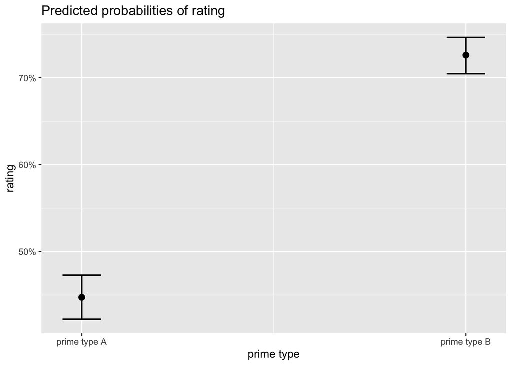

```r
# fit model
model_m1 <- glmer(rating ~ prime_type + (1 | subject),
                  family = binomial(link = "logit"),
                  data = trial_level_posneg_ia_amp_data_exclusions)

# plot
plot_model(model_m1, type = "pred", terms = c("prime_type"))
```

```r
# results table
tab_model(model_m1, emph.p = FALSE, ci.hyphen = ", ")
```

|  | rating |  |  |
| --- | --- | --- | --- |
| Predictors | Odds Ratios | CI | p |
| (Intercept) | 0.81 | 0.73, 0.90 | <0.001 |
| prime_type [prime_type_B] | 3.27 | 3.05, 3.51 | <0.001 |
| Random Effects |  |  |  |
| σ<sup>2</sup> | 3.29 |  |  |
| τ<sub>00</sub> <sub>subject</sub> | 0.44 |  |  |
| ICC | 0.12 |  |  |
| N <sub>subject</sub> | 207 |  |  |
| Observations | 14904 |  |  |
| Marginal R<sup>2</sup> / Conditional R<sup>2</sup> | 0.086 / 0.194 |  |  |

## M2: Demonstate an AMP effect on the politics IA AMP

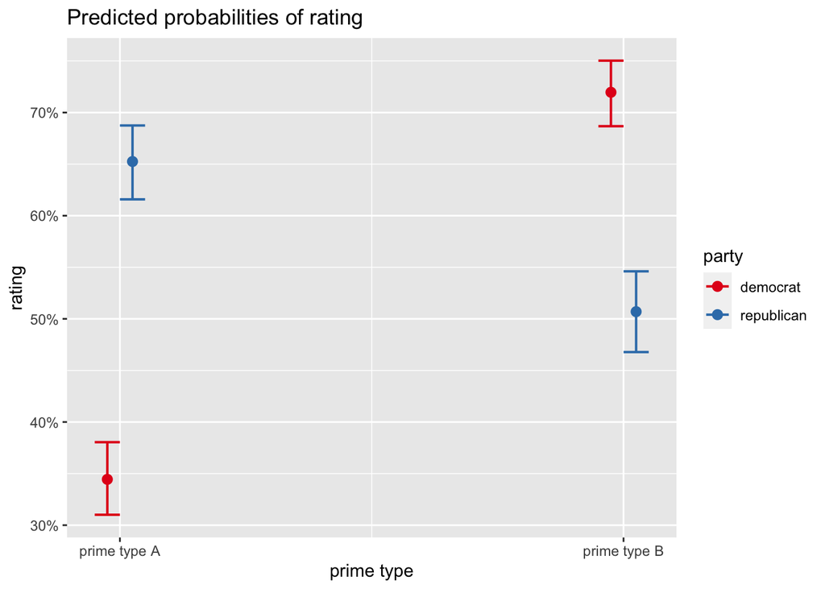

```r
# fit model
model_m2 <- glmer(rating ~ prime_type * party + (1 | subject),
                  family = binomial(link = "logit"),
                  data = trial_level_politics_ia_amp_data_exclusions)

# plot
plot_model(model_m2, type = "int")
```

```r
# results table
tab_model(model_m2, emph.p = FALSE, ci.hyphen = ", ")
```

|  | rating |  |  |
| --- | --- | --- | --- |
| Predictors | Odds Ratios | CI | p |
| (Intercept) | 0.53 | 0.45, 0.61 | <0.001 |
| prime_type [prime_type_B] | 4.89 | 4.41, 5.41 | <0.001 |
| party [republican] | 3.57 | 2.86, 4.46 | <0.001 |
| prime_type [prime_type_B] * party [republican] | 0.11 | 0.10, 0.13 | <0.001 |
| Random Effects |  |  |  |
| σ<sup>2</sup> | 3.29 |  |  |
| τ<sub>00</sub> <sub>subject</sub> | 0.53 |  |  |
| ICC | 0.14 |  |  |
| N <sub>subject</sub> | 207 |  |  |
| Observations | 14904 |  |  |
| Marginal R<sup>2</sup> / Conditional R<sup>2</sup> | 0.089 / 0.215 |  |  |

# Hypothesis tests

## H1: Does IA-AMP influence-awareness predict AMP effects in the same IA-AMP

### H1a: Politics IA-AMP

#### 1: at the trial level

Does conscious awareness of influence of the prime on the target moderate the AMP effect?

Key effect: influence:prime_type:party interaction

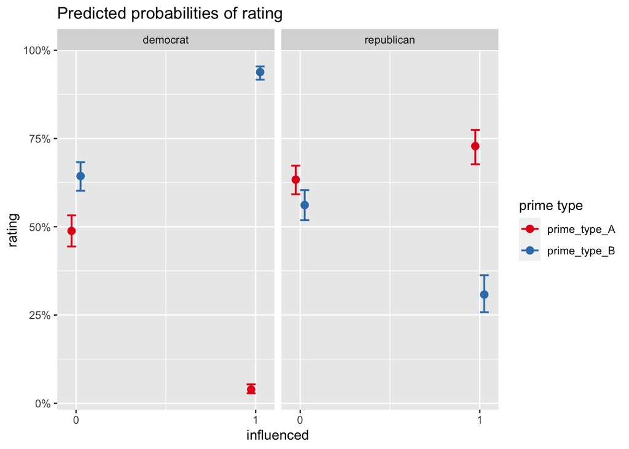

```r
# model
model_h1a_1 <- glmer(rating ~ influenced * prime_type * party + (1 | subject),
                     family = binomial(link = "logit"),
                     data = trial_level_politics_ia_amp_data_exclusions)

# plot
plot_model(model_h1a_1, type = "int")
```

```r
# results table
tab_model(model_h1a_1, emph.p = FALSE, ci.hyphen = ", ", digits = 5)
```

|  | rating |  |  |
| --- | --- | --- | --- |
| Predictors | Odds Ratios | CI | p |
| (Intercept) | 0.95385 | 0.79953, 1.13795 | 0.600 |
| influenced [1] | 0.04245 | 0.03050, 0.05908 | <0.001 |
| prime_type [prime_type_B] | 1.89341 | 1.68912, 2.12241 | <0.001 |
| party [republican] | 1.81228 | 1.41391, 2.32291 | <0.001 |
| influenced [1] * prime_type [prime_type_B] | 197.70477 | 131.64619, 296.91080 | <0.001 |
| influenced [1] * party [republican] | 36.53660 | 24.48701, 54.51555 | <0.001 |
| prime_type [prime_type_B] * party [republican] | 0.39129 | 0.33394, 0.45849 | <0.001 |
| (influenced [1] prime_type [prime_type_B]) party [republican] | 0.00113 | 0.00070, 0.00183 | <0.001 |
| Random Effects |  |  |  |
| σ<sup>2</sup> | 3.29 |  |  |
| τ<sub>00</sub> <sub>subject</sub> | 0.62 |  |  |
| ICC | 0.16 |  |  |
| N <sub>subject</sub> | 207 |  |  |
| Observations | 14904 |  |  |
| Marginal R<sup>2</sup> / Conditional R<sup>2</sup> | 0.267 / 0.382 |  |  |

#### 2: at the participant level

Does rate of influence in the IA-AMP predict IA-AMP effects?

If effects in the IA-AMP are driven by intentional responding, then the size of the effect in the IA-AMP should be moderated by the subset of participants who are more often influenced by the primes.

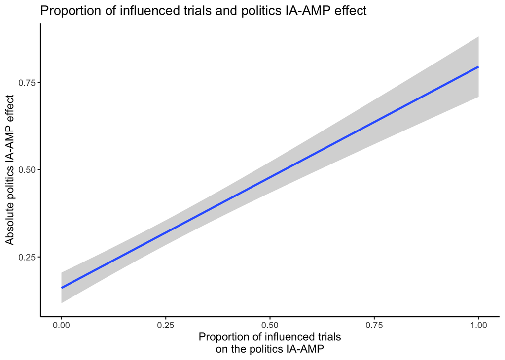

```r
# model
fit_h1b_2 <- task_level_data_exclusions %>%
  mutate(abs_IA_AMP_effect_obama_trump = abs(IA_AMP_effect_obama_trump)) %>%
  lm(abs_IA_AMP_effect_obama_trump ~ influence_rate_obama_trump, data = .)

# plot
ggplot(task_level_data_exclusions, aes(influence_rate_obama_trump, abs(IA_AMP_effect_obama_trump))) +
  geom_smooth(method = lm) +
  labs(title = "Proportion of influenced trials and politics IA-AMP effect",
       x = "Proportion of influenced trials\non the politics IA-AMP",
       y = "Absolute politics IA-AMP effect") +
  theme_classic()
```

```r
# results table
tab_model(fit_h1b_2, emph.p = FALSE, ci.hyphen = ", ", show.std = TRUE, col.order = c("est", "ci", "std.est", "std.ci", "p"))
```

|  | abs IA AMP effect obama trump |  |  |  |  |
| --- | --- | --- | --- | --- | --- |
| Predictors | Estimates | CI | std. Beta | standardized CI | p |
| (Intercept) | 0.16 | 0.12, 0.21 | -0.00 | -0.11, 0.11 | <0.001 |
| influence_rate_obama_trump | 0.63 | 0.53, 0.74 | 0.64 | 0.54, 0.75 | <0.001 |
| Observations | 207 |  |  |  |  |
| R<sup>2</sup> / R<sup>2</sup> adjusted | 0.411 / 0.408 |  |  |  |  |

### H1b: Positive-Negative IA-AMP

#### 1. At the trial level

Does conscious awareness of influence of the prime on the target moderate the AMP effect?

Key effect: influence*prime_type interaction

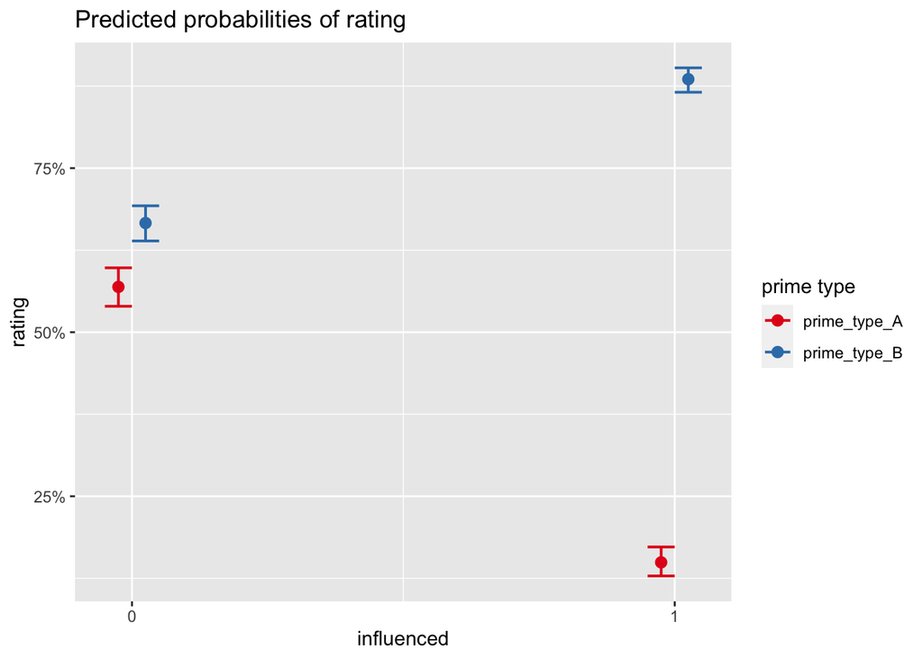

```r
# model
model_h1b_1 <- glmer(rating ~ influenced * prime_type + (1 | subject),
                     family = binomial(link = "logit"),
                     data = trial_level_posneg_ia_amp_data_exclusions)

# plot
plot_model(model_h1b_1, type = "pred", terms = c("influenced", "prime_type"))
```

```r
# results table
tab_model(model_h1b_1, emph.p = FALSE, ci.hyphen = ", ")
```

|  | rating |  |  |
| --- | --- | --- | --- |
| Predictors | Odds Ratios | CI | p |
| (Intercept) | 1.32 | 1.17, 1.49 | <0.001 |
| influenced [1] | 0.13 | 0.11, 0.16 | <0.001 |
| prime_type [prime_type_B] | 1.51 | 1.39, 1.64 | <0.001 |
| influenced [1] * prime_type [prime_type_B] | 29.14 | 23.72, 35.79 | <0.001 |
| Random Effects |  |  |  |
| σ<sup>2</sup> | 3.29 |  |  |
| τ<sub>00</sub> <sub>subject</sub> | 0.55 |  |  |
| ICC | 0.14 |  |  |
| N <sub>subject</sub> | 207 |  |  |
| Observations | 14904 |  |  |
| Marginal R<sup>2</sup> / Conditional R<sup>2</sup> | 0.217 / 0.330 |  |  |

#### 2. At the participant level

Does rate of influence in the IA-AMP predict IA-AMP effects?

If effects in the IA-AMP are driven by intentional responding, then the size of the effect in the IA-AMP should be moderated by the subset of participants who are more often influenced by the primes.

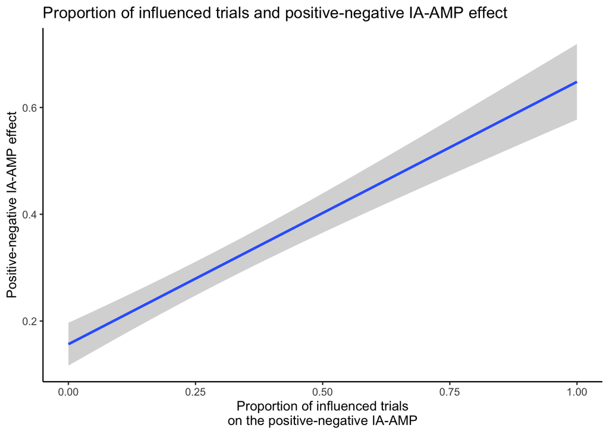

```r
# model
fit_h1b_2 <- task_level_data_exclusions %>%
  mutate(abs_IA_AMP_effect_positive_negative = abs(IA_AMP_effect_positive_negative)) %>%
  lm(abs_IA_AMP_effect_positive_negative ~ influence_rate_positive_negative, data = .)

# plot
ggplot(task_level_data_exclusions, aes(influence_rate_positive_negative,
                                       abs(IA_AMP_effect_positive_negative))) +
  geom_smooth(method = lm) +
  labs(title = "Proportion of influenced trials and positive-negative IA-AMP effect",
       x = "Proportion of influenced trials\non the positive-negative IA-AMP",
       y = "Positive-negative IA-AMP effect") +
  theme_classic()
```

```r
# results table
tab_model(fit_h1b_2, emph.p = FALSE, ci.hyphen = ", ", show.std = TRUE, col.order = c("est", "ci", "std.est", "std.ci", "p"))
```

|  | abs IA AMP effect positive negative |  |  |  |  |
| --- | --- | --- | --- | --- | --- |
| Predictors | Estimates | CI | std. Beta | standardized CI | p |
| (Intercept) | 0.16 | 0.12, 0.20 | 0.00 | -0.11, 0.11 | <0.001 |
| influence_rate_positive_negative | 0.49 | 0.40, 0.58 | 0.61 | 0.50, 0.72 | <0.001 |
| Observations | 207 |  |  |  |  |
| R<sup>2</sup> / R<sup>2</sup> adjusted | 0.370 / 0.367 |  |  |  |  |

## H2: Influence rate in one IA-AMP predicts the absolute magnitude of the other IA-AMP effect

If effects in the AMPs are driven by participants who are more often influenced, then rate of influence in one IA-AMP should predict effect sizes in the other.

### H2a: Politics influence rate, pos-neg effect size

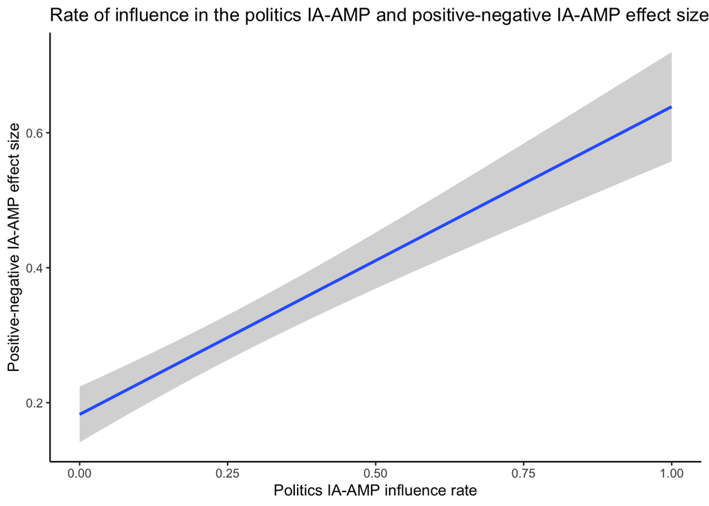

```r
# model
fit_h2a <- task_level_data_exclusions %>%
  mutate(abs_IA_AMP_effect_positive_negative = abs(IA_AMP_effect_positive_negative)) %>%
  lm(abs_IA_AMP_effect_positive_negative ~ influence_rate_obama_trump, data = .)

# plot
ggplot(task_level_data_exclusions, aes(influence_rate_obama_trump,
                                       abs(IA_AMP_effect_positive_negative))) +
  geom_smooth(method = lm) +
  labs(title = "Rate of influence in the politics IA-AMP and positive-negative IA-AMP effect size",
       x = "Politics IA-AMP influence rate",
       y = "Positive-negative IA-AMP effect size") +
  theme_classic()
```

```r
# table
tab_model(fit_h2a, emph.p = FALSE, ci.hyphen = ", ", show.std = TRUE, col.order = c("est", "ci", "std.est", "std.ci", "p"))
```

|  | abs IA AMP effect positive negative |  |  |  |  |
| --- | --- | --- | --- | --- | --- |
| Predictors | Estimates | CI | std. Beta | standardized CI | p |
| (Intercept) | 0.18 | 0.14, 0.22 | -0.00 | -0.12, 0.12 | <0.001 |
| influence_rate_obama_trump | 0.46 | 0.36, 0.55 | 0.54 | 0.42, 0.66 | <0.001 |
| Observations | 207 |  |  |  |  |
| R<sup>2</sup> / R<sup>2</sup> adjusted | 0.292 / 0.288 |  |  |  |  |

### H2b: Pos-neg influence rate, politics effect size

If the positive-negative IA AMP’s influence rate predicts the (previously completed) politics IA-AMP’s effect then this implies that the rate of influence is reliable within participants/across IA AMPs.

Here we use the absolute politics AMP effect size, as the effects are necessarily opposite for Republicans and Democrats. Hence, we use absolute values as we are only interested in magnitude, not direction, of the effect.

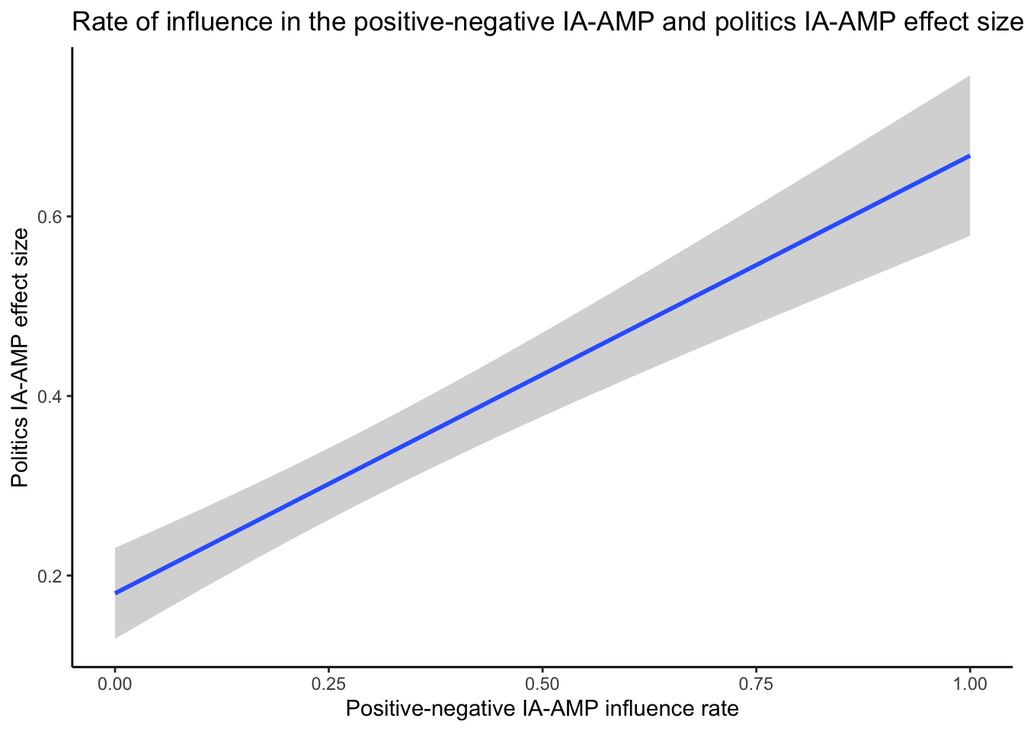

```r
# model
fit_h2b <- task_level_data_exclusions %>%
  mutate(abs_IA_AMP_effect_obama_trump = abs(IA_AMP_effect_obama_trump)) %>%
  lm(abs_IA_AMP_effect_obama_trump ~ influence_rate_positive_negative,data = .)

# plot
ggplot(task_level_data_exclusions, aes(influence_rate_positive_negative,
                                       abs(IA_AMP_effect_obama_trump))) +
  geom_smooth(method = lm) +
  labs(title = "Rate of influence in the positive-negative IA-AMP and politics IA-AMP effect size",
       x = "Positive-negative IA-AMP influence rate",
       y = "Politics IA-AMP effect size") +
  theme_classic()
```

```r
# table
tab_model(fit_h2b, emph.p = FALSE, ci.hyphen = ", ", show.std = TRUE, col.order = c("est", "ci", "std.est", "std.ci", "p"))
```

|  | abs IA AMP effect obama trump |  |  |  |  |
| --- | --- | --- | --- | --- | --- |
| Predictors | Estimates | CI | std. Beta | standardized CI | p |
| (Intercept) | 0.18 | 0.13, 0.23 | -0.00 | -0.12, 0.12 | <0.001 |
| influence_rate_positive_negative | 0.49 | 0.38, 0.60 | 0.52 | 0.40, 0.63 | <0.001 |
| Observations | 207 |  |  |  |  |
| R<sup>2</sup> / R<sup>2</sup> adjusted | 0.266 / 0.262 |  |  |  |  |

## H3: Influence-awareness rate correlates between IA-AMPs across different domains

If the subset of participants who respond intentionally in the AMP are consistent across procedures, then then influence rates in the AMP should correlate.

```r
# test
cor.test(task_level_data_exclusions$influence_rate_obama_trump,
         task_level_data_exclusions$influence_rate_positive_negative,
         paired = TRUE) %>%
  tidy()
```

```
## # A tibble: 1 x 8
##   estimate statistic  p.value parameter conf.low conf.high method    alternative
##      <dbl>     <dbl>    <dbl>     <int>    <dbl>     <dbl> <chr>     <chr>
## 1    0.824      20.8 2.17e-52       205    0.774     0.863 Pearson'… two.sided
```

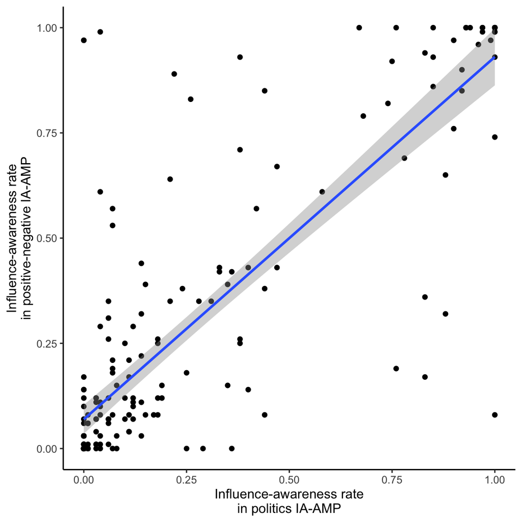

```r
# plot
ggplot(task_level_data_exclusions,
       aes(influence_rate_obama_trump, influence_rate_positive_negative)) +
  geom_point() +
  geom_smooth(method = "lm") +
  labs(x = "Influence-awareness rate\nin politics IA-AMP", y = "Influence-awareness rate\nin positive-negative IA-AMP") +
  theme_classic() +
  ylim(0,1) +
  xlim(0,1)
```

## H4: The politics IA-AMPs ability to predict political affiliation is driven by the subset of trials on which participants reporting being influenced

### Group membership predicting AMP effect from influenced trials

```r
refactored_influenced <- task_level_data_exclusions %>%
  select(IA_AMP_effect_obama_trump_influenced, party) %>%
  na.omit() %>%
  mutate(party = as.factor(as.character(party))) # need to refactor party as it thought it had 3 levels

# test
t.test(IA_AMP_effect_obama_trump_influenced ~ party,
       data = refactored_influenced,
       var.equal = TRUE)
```

```
##
##  Two Sample t-test
##
## data:  IA_AMP_effect_obama_trump_influenced by party
## t = 11.096, df = 112, p-value < 2.2e-16
## alternative hypothesis: true difference in means is not equal to 0
## 95 percent confidence interval:
##  0.8464302 1.2144359
## sample estimates:
##   mean in group democrat mean in group republican
##                0.8421311               -0.1883019
```

```r
# Cohen's d
d_inf <- effsize::cohen.d(IA_AMP_effect_obama_trump_influenced ~ party,
                          data = refactored_influenced)

d_inf
```

```
##
## Cohen's d
##
## d estimate: 2.083583 (large)
## 95 percent confidence interval:
##    lower    upper
## 1.621867 2.545299
```

### Group membership predicting AMP effect from noninfluenced trials

```r
refactored_uninfluenced <- task_level_data_exclusions %>%
  select(IA_AMP_effect_obama_trump_uninfluenced, party) %>%
  na.omit() %>%
  mutate(party = as.factor(as.character(party)))

# test
t.test(IA_AMP_effect_obama_trump_uninfluenced ~ party,
       data = refactored_uninfluenced, var.equal = TRUE)
```

```
##
##  Two Sample t-test
##
## data:  IA_AMP_effect_obama_trump_uninfluenced by party
## t = 4.33, df = 191, p-value = 2.405e-05
## alternative hypothesis: true difference in means is not equal to 0
## 95 percent confidence interval:
##  0.1195947 0.3197180
## sample estimates:
##   mean in group democrat mean in group republican
##               0.12298969              -0.09666667
```

```r
# Cohen's d
d_uninf <- effsize::cohen.d(IA_AMP_effect_obama_trump_uninfluenced ~ party,
                            data = refactored_uninfluenced)

d_uninf
```

```
##
## Cohen's d
##
## d estimate: 0.6233642 (medium)
## 95 percent confidence interval:
##     lower     upper
## 0.3325840 0.9141444
```

### Chi square test to compare

Easiest implementation to compare two cohen’s d values is to use the chi square (test for heterogeneity) from the metafor package. Might seem odd to fit a meta analysis here, but it’s the easiest implementation of the test. Only the test for heterogeneity should be reported.

```r
data <- data.frame(yi = c(d_inf$estimate, d_uninf$estimate),
                   sei = c((d_inf$conf.int["upper"] - d_inf$conf.int["lower"])/(2*1.96),
                           (d_uninf$conf.int["upper"] - d_uninf$conf.int["lower"])/(2*1.96)),
                   condition = c("influenced", "uninfluenced")) %>%
  mutate(vi = sei^2)

fit <- rma(yi = yi,
           sei = sei,
           data = data,
           slab = condition)

#forest(fit)

# Q test in meta analysis heterogeneity is exactly equivalent to the below method
summary(fit, digits = 7)
```

```
##
## Random-Effects Model (k = 2; tau^2 estimator: REML)
##
##     logLik    deviance         AIC         BIC        AICc
## -1.4509512   2.9019024   6.9019024   2.9019024  18.9019024
##
## tau^2 (estimated amount of total heterogeneity): 1.0273680 (SE = 1.5077206)
## tau (square root of estimated tau^2 value):      1.0135917
## I^2 (total heterogeneity / total variability):   96.37%
## H^2 (total variability / sampling variability):  27.51
##
## Test for Heterogeneity:
## Q(df = 1) = 27.5117698, p-val = 0.0000002
##
## Model Results:
##
##  estimate         se       zval       pval       ci.lb      ci.ub
## 1.3420085  0.7300194  1.8383191  0.0660154  -0.0888031  2.7728202  .
##
## ---
## Signif. codes:  0 '***' 0.001 '**' 0.01 '*' 0.05 '.' 0.1 ' ' 1
```

#### Plot

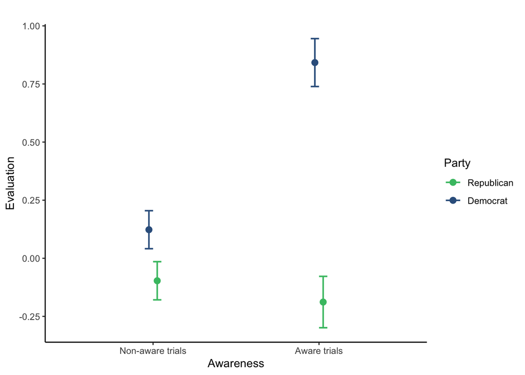

```r
fit <- task_level_data_exclusions %>%
  mutate(Party = dplyr::recode(party,
                               "democrat" = "Democrat",
                               "republican" = "Republican")) %>%
  dplyr::rename("Aware trials" = IA_AMP_effect_obama_trump_influenced,
                "Non-aware trials" = IA_AMP_effect_obama_trump_uninfluenced) %>%
  gather(Awareness,
         Evaluation,
         c("Aware trials", "Non-aware trials")) %>%
  mutate(Awareness = fct_rev(Awareness)) %>%
  lm(data = .,
     Evaluation ~ Awareness * Party)

plot_predictive_valdity <-
  plot_model(fit, type = "int") +
  scale_color_viridis_d(begin = 0.3, end = 0.7) +
  theme_classic() +
  ggtitle("") +
  scale_y_continuous(breaks = c(-.25, -.5, -.75, 0, .25, .5, .75, 1)) +
  #coord_flip() +
  labs(color = "Party") +
  guides(color = guide_legend(reverse = TRUE)) +
  scale_x_discrete(limits = c("Non-aware trials", "Aware trials"),
                   expand = expand_scale(add = 0.65))

# print
plot_predictive_valdity
```

```r
# save object
write_rds(plot_predictive_valdity, "plot_predictive_valdity.rds", compress = "gz")

# save pdf
ggsave(filename  = "plot_predictive_valdity.pdf",
       plot      = plot_predictive_valdity,
       device    = "pdf",
       # path      = NULL,
       # dpi       = 300,
       units     = "in",
       width     = 4.75,
       height    = 3.75,
       limitsize = TRUE)
```